# Pet Cats UK

# Box plot of age by sex

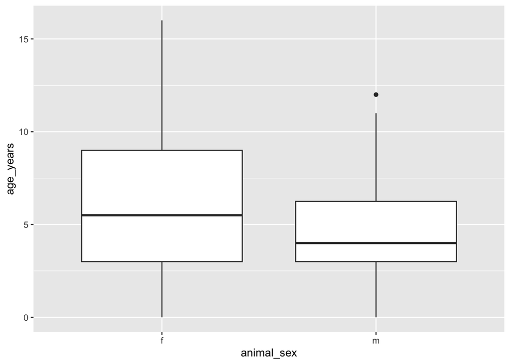

```r
ggplot(pet_cats, aes(x = animal_sex, y = age_years)) +
  geom_boxplot()
```

# Stacked bar plot of num_cats by age group and sex

```r
pet_cats_age_grouped <- pet_cats %>%
  mutate(age_group = cut(age_years, breaks = c(0, 2, 5, 10, Inf))) %>%
  group_by(age_group, animal_sex) %>%
  summarize(mean_num_cats = mean(n_cats))
```

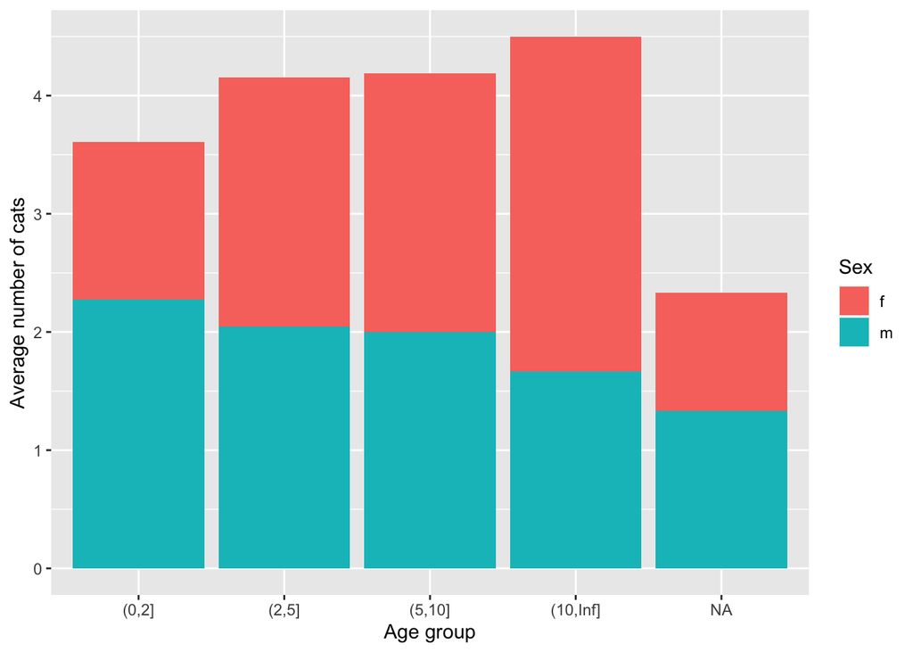

```r
ggplot(pet_cats_age_grouped, aes(x = age_group, y = mean_num_cats, fill = animal_sex)) +
  geom_bar(stat = "identity") +
  labs(x = "Age group", y = "Average number of cats", fill = "Sex")
```

Cat fact #4: While there is some evidence to suggest that female cats may live longer than male cats, the reasons for this are not entirely clear. One factor that may contribute to longer lifespans in female cats is that male cats may be more prone to getting into fights or engaging in other risky behaviors that can lead to injury or illness.

# Cats and hunting

To explore the sex differences in whether the cats were allowed to hunt and how many prey they caught, we can create a series of bar plots and box plots:

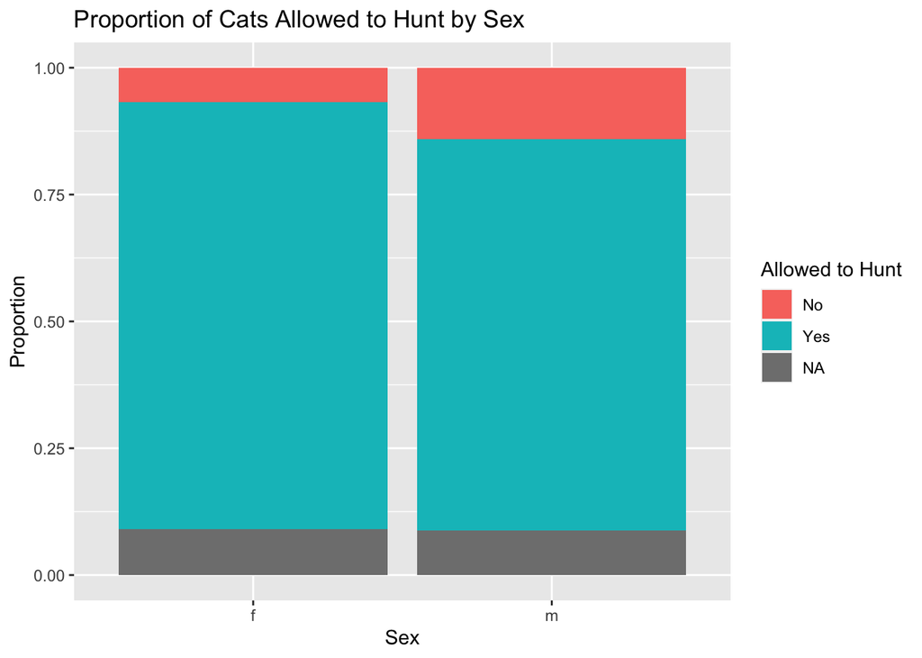

```r
ggplot(pet_cats, aes(x = animal_sex, fill = hunt)) +
  geom_bar(position = "fill") +
  scale_fill_discrete(name = "Allowed to Hunt", labels = c("No", "Yes")) +
  labs(x = "Sex", y = "Proportion") +
  ggtitle("Proportion of Cats Allowed to Hunt by Sex")
```

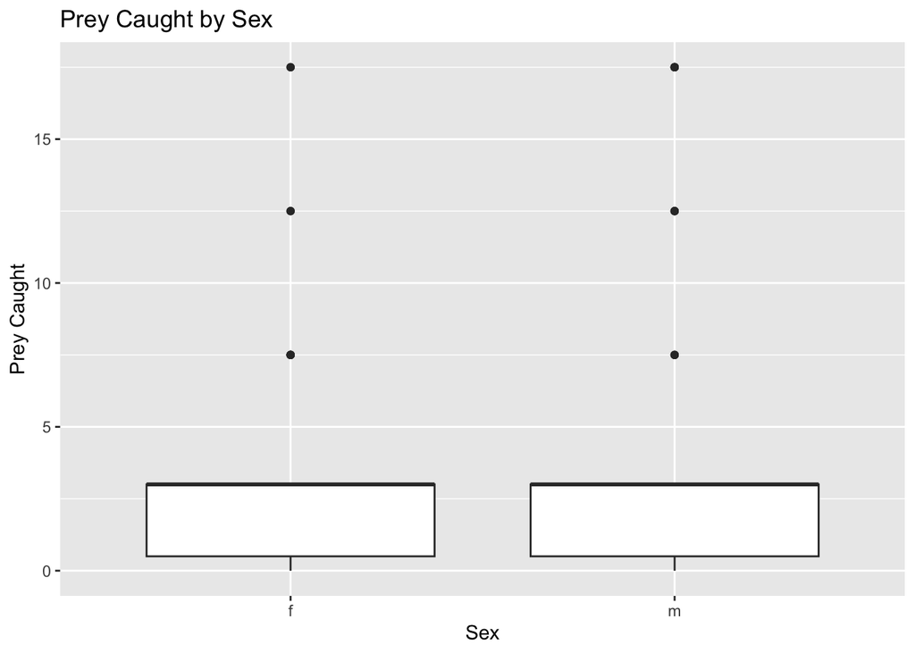

```r
# Box plot of prey caught by sex
ggplot(pet_cats, aes(x = animal_sex, y = prey_p_month)) +
  geom_boxplot() +
  labs(x = "Sex", y = "Prey Caught") +
  ggtitle("Prey Caught by Sex")
```

The second plot shows a box plot of the number of prey caught by sex, with sex on the x-axis and the number of prey caught on the y-axis. From this plot, we can see that male cats caught slightly more prey on average than female cats. To test for significant differences between the groups, we can use t-tests:

```r
# T-test of prey caught by sex
ttest_prey <- t.test(pet_cats$prey_p_month ~ pet_cats$animal_sex)
ttest_prey
```

```
##
##  Welch Two Sample t-test
##
## data:  pet_cats$prey_p_month by pet_cats$animal_sex
## t = -0.028573, df = 98.71, p-value = 0.9773
## alternative hypothesis: true difference in means between group f and group m is not equal to 0
## 95 percent confidence interval:
##  -1.910022  1.855796
## sample estimates:
## mean in group f mean in group m
##        3.727273        3.754386
```

# Relationship between food and age

```r
# Combine logical variables to create new categorical variable

pet_cats$food <- ifelse(pet_cats$food_dry & pet_cats$food_wet, "Mixed",
               ifelse(pet_cats$food_dry, "Dry",
                      ifelse(pet_cats$food_wet, "Wet", "Unknown")))

# View the resulting categorical variable
table(pet_cats$food)
```

```
##
##   Dry Mixed   Wet
##    30    67     4
```

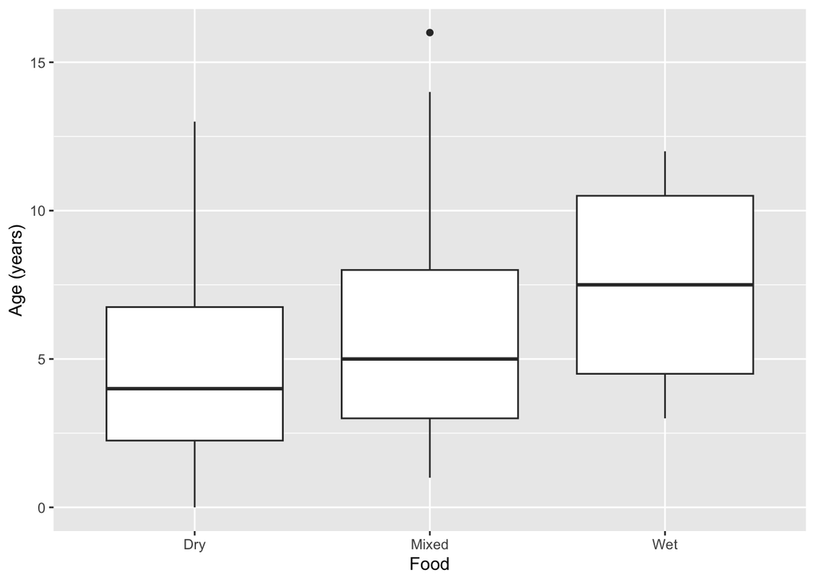

```r
ggplot(pet_cats, aes(x = food, y = age_years)) +
  geom_boxplot() +
  labs(x = "Food", y = "Age (years)")
```

```r
# One-way ANOVA
anova_age_food <- aov(age_years ~ food, data = pet_cats)
summary(anova_age_food)
```

```
##             Df Sum Sq Mean Sq F value Pr(>F)
## food         2   48.3   24.16   2.158  0.121
## Residuals   97 1086.0   11.20
## 1 observation deleted due to missingness
```

Based on the box plot and ANOVA, it appears that there may be a slight difference in the age distribution between the different types of food, with cats fed “Wet” food having a slightly higher median age than cats fed “Dry” or “Mixed” food. However, the effect size is likely small and the statistical significance is not strong. It is also important to note that correlation does not imply causation, and there may be other factors at play that affect the age distribution of cats fed different types of food.

Cat fact #5: The world’s most expensive cat food, called “Bistro Cat,” costs $48 per pound and is made with quail, lobster, and Russian caviar.

# A pretty plot - hours indoors vs. age

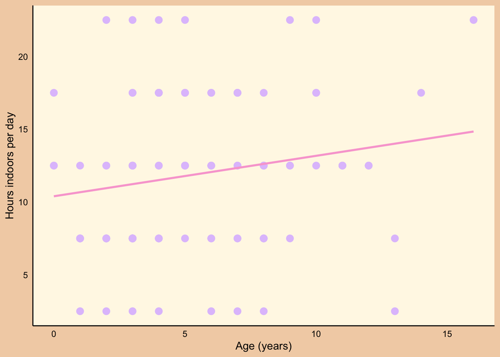

```r
# Create the plot
p <- ggplot(pet_cats, aes(x = age_years, y = hrs_indoors)) +
  geom_point(color = "#E0C3FC", size = 3) +
  geom_smooth(color = "#F9A8D4", method = "lm", se = FALSE) +
  labs(x = "Age (years)", y = "Hours indoors per day") +
  theme_minimal() +
  theme(
    panel.grid.major = element_blank(),
    panel.grid.minor = element_blank(),
    panel.border = element_blank(),
    axis.line = element_line(color = "black"),
    axis.text = element_text(color = "black"),
    axis.title = element_text(color = "black"),
    legend.position = "none",
    plot.background = element_rect(fill = "#F2D2B3", color = NA),
    panel.background = element_rect(fill = "#FFF8E7", color = NA)
  )

p
```

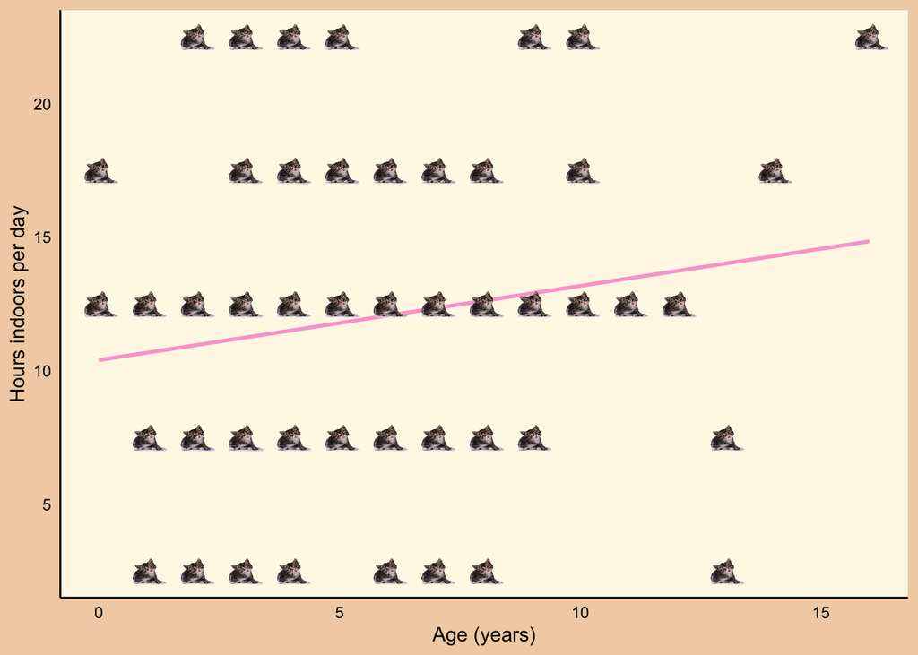

```r
# Add cat-themed data points (p plus cat)
p + (geom_image(mapping = aes(x = age_years, y = hrs_indoors, image = 'https://static.wixstatic.com/media/2cd43b_b4adb5c56af247fb8e36d1433149b079~mv2.png/v1/fill/w_227,h_228,q_90/2cd43b_b4adb5c56af247fb8e36d1433149b079~mv2.png')))
```

# Twitter can help us

This code creates a scatterplot with points colored by sex, where each point represents a cat’s age and the number of hours they spend indoors each day. The geom_label_repel() function adds labels to each point, displaying the cat’s name. The code was shared by @MaxTheMojo1 on Twitter.

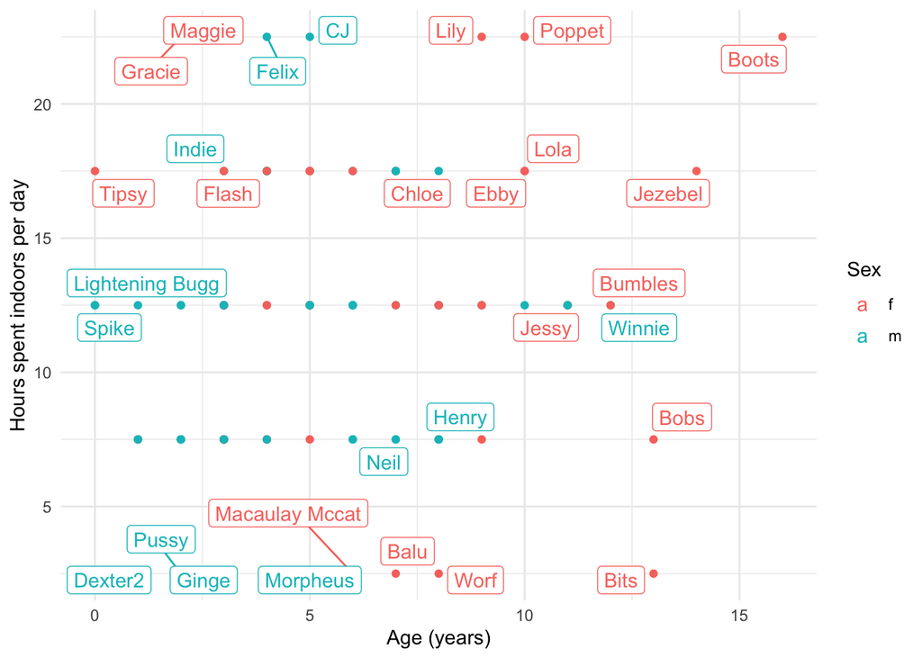

```r
library(ggrepel)

pet_cats %>%
  ggplot(aes(x = age_years, y = hrs_indoors, color = animal_sex)) +
  geom_point() +
  theme_minimal() +
  labs(x = "Age (years)", y = "Hours spent indoors per day", color = "Sex") +
  geom_label_repel(aes(label = animal_id))
```

# Some puns to finish

1. What do you call a pile of cats? A meowtain.
2. Why was the cat sitting on the computer? It wanted to keep an eye on the mouse!
3. What do you get when you cross a cat and a lemon? A sourpuss!
4. Why did the cat wear a fancy dress? She was feline fine!
5. What do you call a cat magician? A catastrophe!